# Simple Tree Building in R

Samantha Lycett

23 Feb 2024

# Simple Tree Building in R

## Automating Trees in R

R package ape provides some functions which enable reading sequences from fasta files; Neighbour joining tree building; Simple tree plotting; Finding the best root and performing a root-to-tip plot; from Root-to-Tip plot you can find the estimated clock rate and time to most recent common ancestor.

Here is example R script to show how a Neighbour joining tree can be built from a set of fasta sequences, and how to perform a Root-to-Tip molecular clock analyses (similar to Tempest).

```r
# install R package ape if needed (only do this once)
#install.packages("ape")

# load required library (do this every time)
library(ape)

# load custom functions (utility code for sequence or tree tips names)
source("getEl.R")
source("calcDecimalDate.R")
```

## STEP 1 - read sequences from file

```r
# read sequences into seqs object using R package ape and read.dna function
seqFileName <-  "H5N1_HA_sel5regions.fas"
seqs        <- read.dna(seqFileName,format="fasta",as.matrix=FALSE)

# number of sequences
nseqs       <- length(seqs)
```

There were 92 sequences read from H5N1_HA_sel5regions.fas

The sequence names are within the seqs object, the first 5 are:

```r
attributes(seqs)$names[1:5]
```

```
## [1] "ABR13964|Dom-ans|EasternAsia|A/duck/Hunan/15/2004|2004.074"
## [2] "ACN39417|Dom-ans|EasternAsia|A/duck/Hunan/1964/2007|2007.060"
## [3] "ADD10547|Dom-ans|EasternAsia|A/duck/Eastern_China/909/2009|2009.038"
## [4] "AEO52356|Dom-ans|EasternAsia|A/duck/Zhejiang/224/2011|2011.123"
## [5] "AER09583|Dom-ans|EasternAsia|A/duck/Korea/Cheonan/2010|2010.953"
```

Here we can see the format of the sequences names, it is Accession|Host-type|Region|IsolateName|decimalDate

The distribution of Host-types in the data set is:

```r
taxa <- as.matrix(attributes(seqs)$names)
host <- apply(taxa,1,getEl,ind=2,sep="\\|")
kable(t(table(host)), caption="Host-types")
```

Host-types

| Dom-ans | Dom-gal | Wild-ans |
| --- | --- | --- |
| 36 | 42 | 14 |

```r
region <- apply(taxa,1,getEl,ind=3,sep="\\|")
kable(t(table(region)), caption="Region")
```

Region

| Africa | EasternAsia | Europe | SouthEasternAsia | SouthernAsia |
| --- | --- | --- | --- | --- |
| 23 | 23 | 12 | 23 | 11 |

## STEP 2 - make distance matrix

Use the TN93 (Tamura-Nei 93) nucleotide substitution model, assume gamma distributed rates between sites with a gamma distribution shape parameter of 0.1, and allow pairwise deletion

```r
dd          <- dist.dna(seqs,model="TN93",gamma=0.1,pairwise.deletion=TRUE)
```

## STEP 3 - make Neighbour joining tree

Now use the just created distance matrix to make a neighbour joining tree with function nj. Plot the tree without showing the tip labels

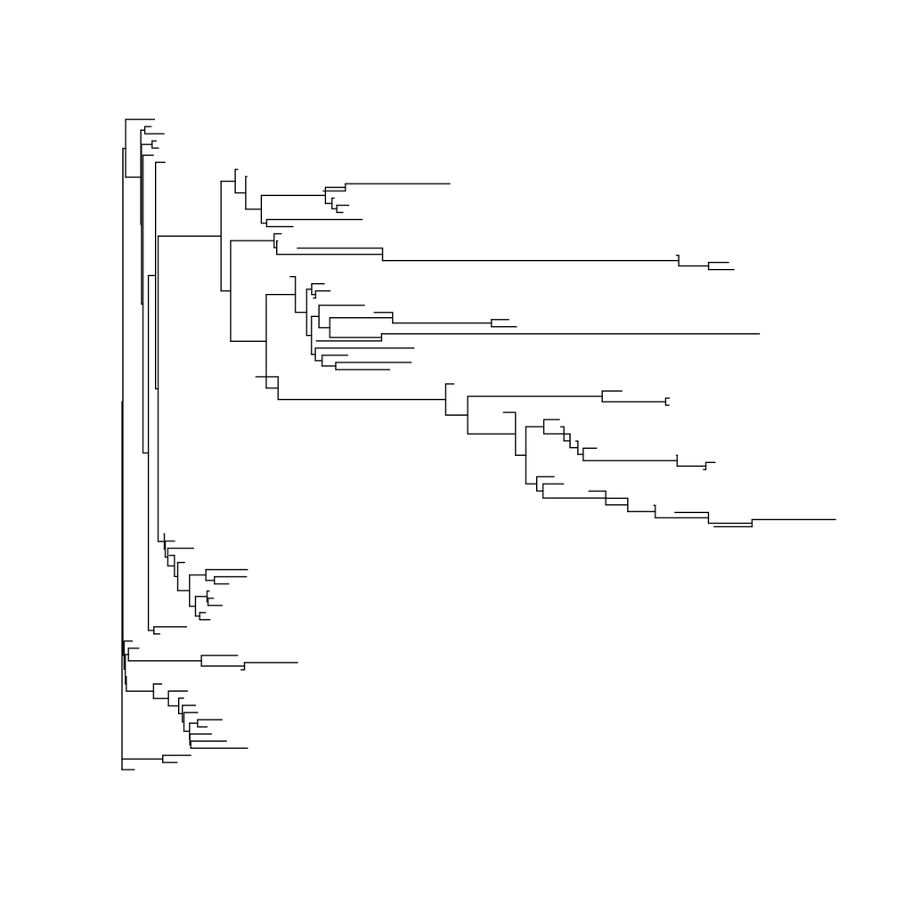

```r
tr  <- nj(dd)
plot(tr, show.tip.label=FALSE)
```

Reorder the branches of the tree using function ladderize and replot the tree (notice how it looks different)

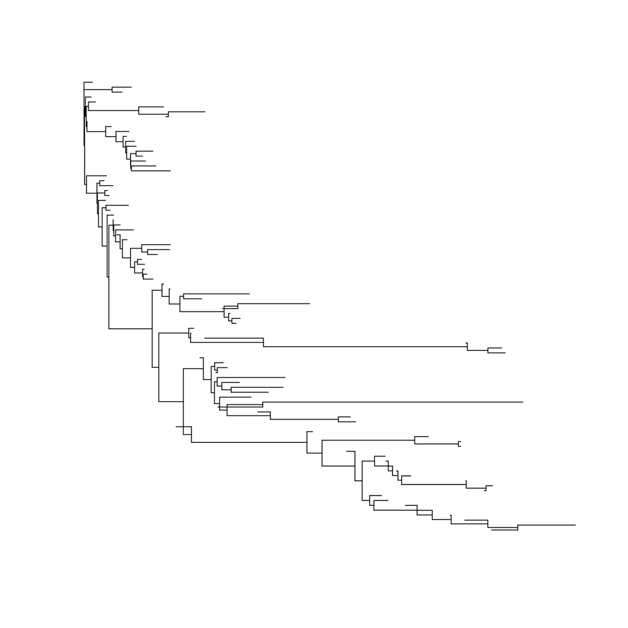

```r
tr  <- ladderize(tr)
plot(tr, show.tip.label=FALSE)
```

Save the tree to file in newick format

```r
treeFileName<- gsub(".fas","_ape_tn93_nj.nwk",seqFileName)
write.tree(tr, file=treeFileName)
```

The tree has been written to file H5N1_HA_sel5regions_ape_tn93_nj.nwk

## STEP 4 - Rooting the tree using root-to-tip

Extract the decimal dates from the carefully constructed sequence names. The sequence names have the decimal date encoded at the end separated by a bar.

The first sequence name in the tree (first taxa) is: ABR13964|Dom-ans|EasternAsia|A/duck/Hunan/15/2004|2004.074

The first 5 sequences in the tree are the following (note the order is not necessarily the same as in the sequences file used to generate the tree):

```r
tr$tip.label[1:5]
```

```
## [1] "ABR13964|Dom-ans|EasternAsia|A/duck/Hunan/15/2004|2004.074"
## [2] "ACN39417|Dom-ans|EasternAsia|A/duck/Hunan/1964/2007|2007.060"
## [3] "ADD10547|Dom-ans|EasternAsia|A/duck/Eastern_China/909/2009|2009.038"
## [4] "AEO52356|Dom-ans|EasternAsia|A/duck/Zhejiang/224/2011|2011.123"
## [5] "AER09583|Dom-ans|EasternAsia|A/duck/Korea/Cheonan/2010|2010.953"
```

```r
# uses custom function getEl
decDates  <- as.numeric(apply(as.matrix(tr$tip.label),1,getEl,ind=1,fromEnd=TRUE,sep="\\|"))
```

Use the rtt (root to tip) function from R package ape, this uses the decimal dates and tries to find the best fitting root. It returns a rooted tree.

```r
# find best rooted tree using rtt function and decimal dates (decDates)
rtr <- rtt(tr,decDates)

# save the best rooted tree
tname<- gsub(".nwk","_rtt.nwk",treeFileName)
write.tree(rtr, file=tname)
```

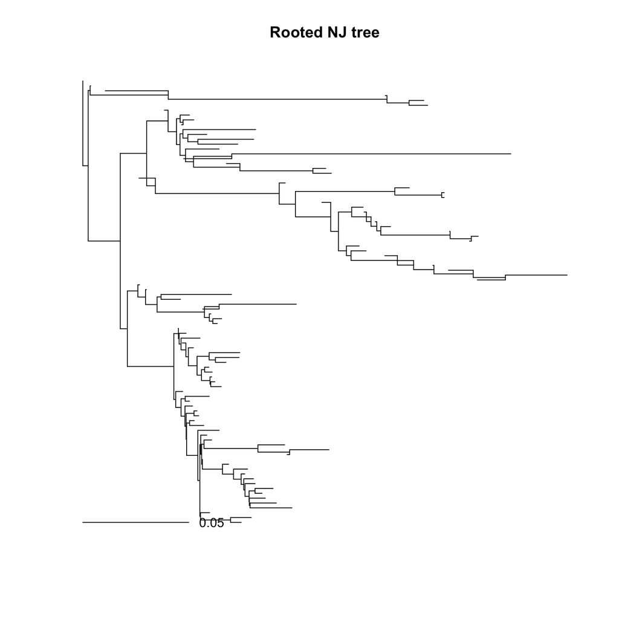

```r
plot(rtr, show.tip.label=FALSE)
title("Rooted NJ tree")
add.scale.bar()
```

## Step 5 - Get Root to tip plot and extract clock rate and TMRCA

Get root to tip information, this is the genetic distance from the root. Use function dist.nodes - which calculated the genetic distance from the root node to all the nodes of the tree.

```r
# get the genetic distance (all nodes)
rtt_all_dists<- dist.nodes(rtr)
ntips        <- length(rtr$tip.label)
rootNode     <- length(rtr$tip.label)+1

# get the genetic distance from the rootNode to all the sequences (tips)
rootToTip    <- rtt_all_dists[1:ntips,rootNode]
```

Fit a straight line (i.e. linear model, lm) to the genetic distance from root (rootToTip) vs time (decDates)

```r
clock_fit    <- lm(rootToTip ~ decDates)
```

Extract the slope of the line from the line fit - which is the clock rate, but round it abit for easier printing to screen.

```r
clockrate    <- round(clock_fit$coefficients[2]*100000)/100000
```

Extract the intercept of the line - this is the TMRCA, but round it abit for easier printing to screen

```r
tmrca        <- -clock_fit$coefficients[1]/clock_fit$coefficients[2]
tmrca        <- round(tmrca*1000)/1000
```

Show root to tip plot

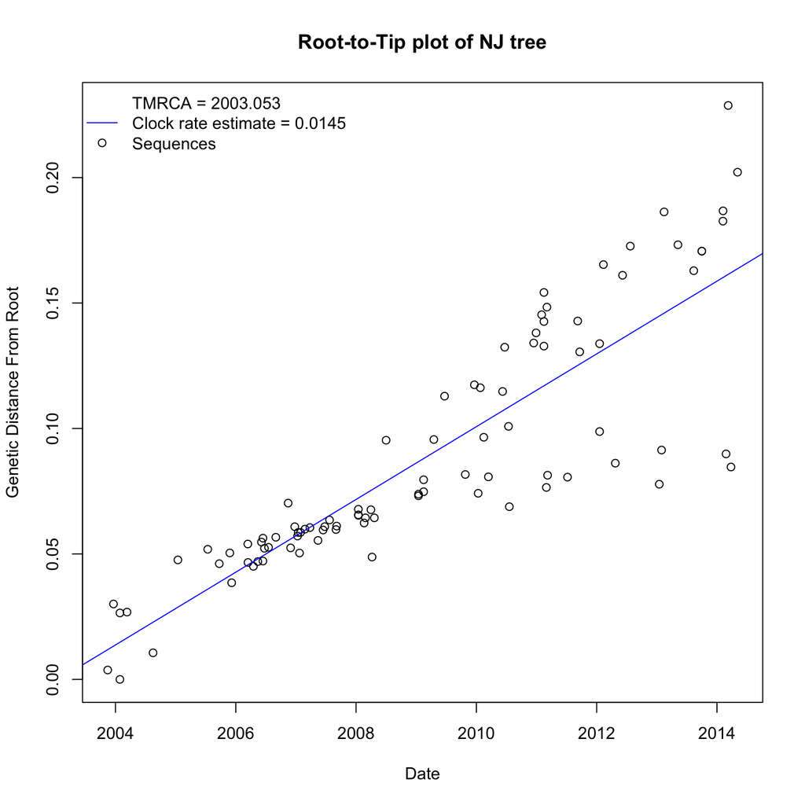

```r
plot(decDates,rootToTip,pch=21,
     xlab="Date", ylab="Genetic Distance From Root")
abline(clock_fit,col="blue")
legend("topleft",c(paste("TMRCA =",tmrca),
                   paste("Clock rate estimate =",clockrate),
                   "Sequences"),
       pch=c(NA,NA,21), col=c(NA,"blue","black"), lty=c(NA,1,NA),bty="n")
title("Root-to-Tip plot of NJ tree")
```